# EDA of Anthony Fantano's (aka theneedledrop) album reviews

```python
import pandas as pd
import numpy as np
%matplotlib inline
import matplotlib as plt
from matplotlib import pyplot
import seaborn as sns
import scipy.stats as stats
from scipy.stats import chi2_contingency
from scipy.stats import chi2
```

Anthony Fantano, a.k.a. Melon, is an American music critic, video producer and journalist best known for creating the Needle Drop, a music-related video blog. He is self-described as "the internet's busiest music nerd". Fantano's website and YouTube channel review a variety of music genres, including pop, hip-hop, rock, metal, indie, electronic, folk, jazz and experimental.

Today we will be doing Exploratory Data Analysis on a music reviews dataset that I scraped from Fantano's website via Scrapy. Like in the real world, most of my time during this project will be dedicated to tidying the data. If you would like to play around with this dataset, check out my github at https://github.com/AntEDra/theNeedleDrop.

There's a lot to explore here. Does Fantano have any biases for/against particular genres? Has he been more harsh/lenient in his reviews earlier in his music reviewing career? With nearly 1200 rows of data, we will find the answers to these, plus more!

```python
#path of data
path = 'C:/Users/capnf/needleDropScraper/theneedledrop/theneedledrop.csv'
df = pd.read_csv(path)
df
```

|  | album | artist | date | genre | name | score | tags | url |
| --- | --- | --- | --- | --- | --- | --- | --- | --- |
| 0 | Avow | Portal | 2021-06-04T02:23:00-0400 | loud rock | Portal - Avow | 5 | portal \| avow \| 2021 \| album \| profound lore \|... | https://www.theneedledrop.com/articles/2021/6/... |
| 1 | Scaled and Icy | twenty one pilots | 2021-05-24T15:37:00-0400 | pop | twenty one pilots - Scaled and Icy | 2 | twenty one pilots \| scaled and icy \| 2021 \| al... | https://www.theneedledrop.com/articles/2021/5/... |
| 2 | Yards | Tune | 2021-05-25T11:22:00-0400 | pop | Tune-Yards - sketchy. | 7 | tune-yards \| sketchy \| 2021 \| album \| 4ad \| po... | https://www.theneedledrop.com/articles/2021/5/... |
| 3 | SOUR | Olivia Rodrigo | 2021-05-26T23:39:00-0400 | pop | Olivia Rodrigo - SOUR | 7 | olivia rodrigo \| sour \| 2021 \| album \| debut \|... | https://www.theneedledrop.com/articles/2021/5/... |
| 4 | Hommy | Mach | 2021-05-28T19:47:00-0400 | hip hop | Mach-Hommy - Pray for Haiti | 7 | mach-hommy \| pray for haiti \| 2021 \| album \| g... | https://www.theneedledrop.com/articles/2021/5/... |
| ... | ... | ... | ... | ... | ... | ... | ... | ... |
| 1252 | The Beast of Left and Right | Lazer/Wulf | 2014-07-14T03:33:30-0400 | math rock | Lazer/Wulf - The Beast of Left and Right | lazer | 2014 \| lazer/wulf \| math rock \| progressive \| ... | https://www.theneedledrop.com/articles/2014/07... |
| 1253 | Alternate/Endings | Lee Bannon | 2014-01-17T05:40:13-0500 | electronic | Lee Bannon - Alternate/Endings | alternate | 2014 \| alternate/endings \| breakbeat \| drum 'n... | https://www.theneedledrop.com/articles/2014/01... |
| 1254 | The 20/20 Experience | Justin Timberlake | 2013-03-26T06:48:35-0400 | dance pop | Justin Timberlake - The 20/20 Experience | the 20 | 2013 \| dance pop \| justin timberlake \| mirrors... | https://www.theneedledrop.com/articles/2013/03... |
| 1255 | Manifestations EP | Mono/Poly | 2011-04-16T06:05:16-0400 | electronic | Mono/Poly- Manifestations EP | mono | brainfeeder \| electronic \| forest dark \| manif... | https://www.theneedledrop.com/articles/2011/04... |
| 1256 | Paramatma ‡ REVIEW | Mono/Poly | 2010-07-28T04:36:18-0400 | hip hop | Mono/Poly- Paramatma ‡ REVIEW | mono | dub step \| electro \| hip hop \| mono/poly \| par... | https://www.theneedledrop.com/articles/2010/07... |

1257 rows × 8 columns

Of course, we have to create the dataset and read in the CSV file just to make sure everything is in order. One important thing we need to do is check and make sure that all data is in the correct format (int, float, text or other).

# Tidying the data

```python
print(df.dtypes)
```

```
album     object
artist    object
date      object
genre     object
name      object
score     object
tags      object
url       object
dtype: object
```

Anthony Fantano rates his music on a scale of 0-10. He precedes these scores with "light", "decent", or "strong" (e.g. an album could have a light 7, or a strong 6), but let's ignore that for this EDA. The scoring format should be int, but I cannot convert it to an int yet because some of the rows contain words. I fixed this by dropping rows that don't contain 0-10 then converted the type to int.

```python
df = df[df['score'].isin(['0','1','2','3','4','5','6','7','8','9','10'])]
df[["score"]] = df[["score"]].astype("int")
df.dropna(subset=["score"], axis=0, inplace=True)
df.reset_index(drop=True, inplace=True)
```

```python
print(df.dtypes)
```

```
album     object
artist    object
date      object
genre     object
name      object
score      int32
tags      object
url       object
dtype: object
```

Most of the EDA for this dataset will be using the score, genre, and year columns. Now that we have score as a numerical value we can do proper descriptive statistics for all the album scores.

```python
df.describe()
```

|  | score |
| --- | --- |
| count | 1250.000000 |
| mean | 6.254400 |
| std | 1.644824 |
| min | 0.000000 |
| 25% | 5.000000 |
| 50% | 6.000000 |
| 75% | 8.000000 |
| max | 10.000000 |

I'm not a fan of the date format in this dataset, so I am just going to create a new column that is just the year. This will be a good categorical variable to facet music reviews by later on.

```python
df['year'] = df['date'].str[:4]
df['year'].unique()
```

```
array(['2021', '2020', '2019', '2018', '2017', '2016', '2015'],
      dtype=object)
```

```python
sorted(df["genre"].unique())
```

```
['100% electronica',
 'a$ap rocky',
 'abstract hip hop',
 'aesop rock',
 'another eternity',
 'another one',
 'arena rock',
 'art pop',
 'art rock',
 'asunder sweet and other distress',
 'baroque pop',
 'blues rock',
 'britpop',
 'brockhampton',
 'chamber pop',
 'chemical brothers',
 'conscious hip hop',
 'dream pop',
 'east coast hip hop',
 'electronic',
 'experimental hip hop',
 'experimental pop',
 'experimental rock',
 'folk rock',
 'garage rock',
 'glitch pop',
 'hardcore hip hop',
 'hip hop',
 'i am other',
 'iggy pop',
 'indie pop',
 'indie rock',
 'industrial hip hop',
 'instrumental hip hop',
 'j-pop',
 'jay electronica',
 'jay rock',
 'lo-fi pop',
 'loud rock',
 'math rock',
```

[output cut: 13 more lines]

```
 'pop smoke',
 'pop. 1280',
 'poppy',
 'power pop',
 'progressive electronic',
 'progressive rock',
 'psychedelic pop',
 'psychedelic rock',
 'rock',
 'rocket',
 'southern hip hop',
 'southern rock',
 'sub pop',
 'the last rocket',
 'the pop group']
```

Holy moly that is a lot of genres! Well to be fair, most of these are styles of specific genres (e.g. math rock and post-rock can be summarized as rock). I am going to create a list of all the items in genre_specific that need to be removed (e.g. the scores and record labels).

```python
removeTheseGenre = ['100%','electronica','a$ap rocky','aesop rock','another eternity','another one',
                    'asunder sweet and other distress','brockhampton','chemical brothers','i am other',
                      'iggy pop','jay electronica','jay rock','meridian brothers','mom + pop','moor mother',
                      'norman fucking rockwell','other people','pop 2','pop smoke','pop. 1280','poppy','rocket',
                      'sub pop', 'the last rocket','the pop group']
```

```python
df = df[~df['genre'].str.contains('|'.join(removeTheseGenre))]
df.reset_index(drop=True, inplace=True)
```

```python
sorted(df["genre"].unique())
```

```
['a$ap rocky',
 'abstract hip hop',
 'arena rock',
 'art pop',
 'art rock',
 'baroque pop',
 'blues rock',
 'britpop',
 'chamber pop',
 'conscious hip hop',
 'dream pop',
 'east coast hip hop',
 'electronic',
 'experimental hip hop',
 'experimental pop',
 'experimental rock',
 'folk rock',
 'garage rock',
 'glitch pop',
 'hardcore hip hop',
 'hip hop',
 'indie pop',
 'indie rock',
 'industrial hip hop',
 'instrumental hip hop',
 'j-pop',
 'lo-fi pop',
 'loud rock',
 'math rock',
 'mom + pop',
 'narkopop',
 'noise pop',
 'noise rock',
 'other',
 'pop',
 'pop punk',
 'pop rap',
 'power pop',
 'progressive electronic',
 'progressive rock',
 'psychedelic pop',
 'psychedelic rock',
 'rock',
 'southern hip hop',
 'southern rock']
```

```python
dict = {
    'Hip Hop': ['a$ap rocky','abstract hip hop','conscious hip hop','experimental hip hop','hardcore hip hop',
                'hip hop','instrumental hip hop','pop rap','southern hip hop'],

    'Pop': ['art pop','baroque pop','britpop','chamber pop','dream pop','experimental pop','indie pop','j-pop',
            'lo-fi pop','narkopop','noise pop','pop','power pop','psychedelic pop'],

    'Loud Rock': ['loud rock','noise rock'],

    'Rock': ['arena rock','art rock','blues rock','experimental rock','folk rock','garage rock','indie rock',
             'math rock','pop punk','progressive rock','rock', 'southern rock'],

    'Other': ['mom + pop','other'],

    'Electronic': ['electronic','glitch pop']
    }

d = {genres: cat for cat,l in dict.items() for genres in l}
df['genre_category'] = df['genre'].map(d)
```

```python
missing_data = df.isnull()
for column in missing_data.columns.values.tolist():
    print(column)
    print (missing_data[column].value_counts())
    print("")
```

```
album
False    1195
Name: album, dtype: int64

artist
False    1195
Name: artist, dtype: int64

date
False    1195
Name: date, dtype: int64

genre
False    1195
Name: genre, dtype: int64

name
False    1195
Name: name, dtype: int64

score
False    1195
Name: score, dtype: int64

tags
False    1195
Name: tags, dtype: int64

url
False    1195
Name: url, dtype: int64

year
False    1195
Name: year, dtype: int64

genre_category
False    1190
True        5
Name: genre_category, dtype: int64
```

It looks like some rows didn't have tags that contained any of the values for genre_category, so they came up as missing values. Let's drop these.

```python
df.dropna(subset=["genre_category"], axis=0, inplace=True)
df.reset_index(drop=True, inplace=True)
```

```python
print(df.isnull().sum())
```

```
album             0
artist            0
date              0
genre             0
name              0
score             0
tags              0
url               0
year              0
genre_category    0
dtype: int64
```

And, finally, to now drop a few columns that will provide no value for my EDA of the dataset.

```python
df = df.drop(['date', 'url','genre'], axis=1)
```

```python
df = df[['album','artist','name','genre_category','score','year','tags']]
df.head()
```

|  | album | artist | name | genre_category | score | year | tags |
| --- | --- | --- | --- | --- | --- | --- | --- |
| 0 | Avow | Portal | Portal - Avow | Loud Rock | 5 | 2021 | portal \| avow \| 2021 \| album \| profound lore \|... |
| 1 | Scaled and Icy | twenty one pilots | twenty one pilots - Scaled and Icy | Pop | 2 | 2021 | twenty one pilots \| scaled and icy \| 2021 \| al... |
| 2 | Yards | Tune | Tune-Yards - sketchy. | Pop | 7 | 2021 | tune-yards \| sketchy \| 2021 \| album \| 4ad \| po... |
| 3 | SOUR | Olivia Rodrigo | Olivia Rodrigo - SOUR | Pop | 7 | 2021 | olivia rodrigo \| sour \| 2021 \| album \| debut \|... |
| 4 | Hommy | Mach | Mach-Hommy - Pray for Haiti | Hip Hop | 7 | 2021 | mach-hommy \| pray for haiti \| 2021 \| album \| g... |

Before we get into the EDA, I am sure you all are wondering what the heck is the 'other' genre? And to answer your question, I will perform a query on the dataset and use the best of my knowledge to interpret the query results.

```python
df.loc[df['genre_category'] == 'Other'].head(8)
```

[output not shown]

I do not know any of these artists, except for Hayley Williams (from the band Paramore, for the uninitiated). I looked up the albums for these 8 and they are basically a smörgåsbord of jazz, folk, ambient, etc. Basically rows that belong on the 'other' genre mean that they do not perfectly fit in the other values for genre_category.

# Becoming Familiar with the Data

Lets plot a histogram of album scores to see what the distribution of scores looks like. Melon is known for being a rather tough music critic, but the distribution shows that he mostly gives "positive-leaning" reviews, assuming that 5 is considered THE mediocre review.

|  | score |
| --- | --- |
| count | 1190.000000 |
| mean | 6.221849 |
| std | 1.646525 |
| min | 0.000000 |
| 25% | 5.000000 |
| 50% | 6.000000 |
| 75% | 8.000000 |
| max | 10.000000 |

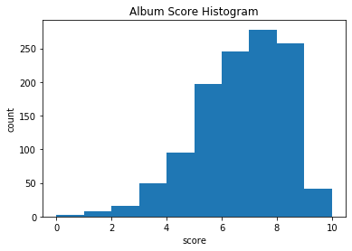

```python
plt.pyplot.hist(df["score"])

plt.pyplot.xlabel("score")
plt.pyplot.ylabel("count")
plt.pyplot.title("Album Score Histogram")
df.describe()
```

Let's bin the score data into 4 categories. Album scores are discrete numbers so it isn't a bad idea to group these into categories, if I decide to do logistical regression using these bins later on. Not to mention it helps add more dimension to visualizations later.

```python
bins = np.linspace(min(df["score"]), max(df["score"]), 5)
group_names = ['BAD','MEH','GOOD','GREAT']
df['score-binned']=pd.cut(df['score'], bins, labels=group_names, include_lowest=True )
df[['album','artist','score','score-binned']].head()
```

|  | album | artist | score | score-binned |
| --- | --- | --- | --- | --- |
| 0 | Avow | Portal | 5 | MEH |
| 1 | Scaled and Icy | twenty one pilots | 2 | BAD |
| 2 | Yards | Tune | 7 | GOOD |
| 3 | SOUR | Olivia Rodrigo | 7 | GOOD |
| 4 | Hommy | Mach | 7 | GOOD |

```python
df['score-binned'].value_counts()
```

```
GOOD     523
MEH      341
GREAT    299
BAD       27
Name: score-binned, dtype: int64
```

```python
df["genre_category"].value_counts()
```

```
Hip Hop       408
Pop           279
Rock          235
Loud Rock     113
Other          82
Electronic     73
Name: genre_category, dtype: int64
```

```python
# grouping results
df_gptest = df[['genre_category','score']]
grouped_test1 = df_gptest.groupby(['genre_category'],as_index=False).mean()
grouped_test1
```

|  | genre_category | score |
| --- | --- | --- |
| 0 | Electronic | 6.397260 |
| 1 | Hip Hop | 5.835784 |
| 2 | Loud Rock | 6.690265 |
| 3 | Other | 6.804878 |
| 4 | Pop | 6.283154 |
| 5 | Rock | 6.336170 |

The chart above, and the boxplot below gives us a visual of the distribution of review score based on genre. These don't seem to provide any groundbreaking insights, just an indication that hip-hop is the most reviewed genre.

[output not shown]

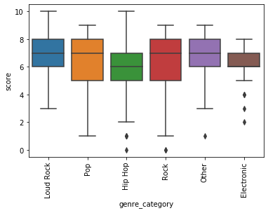

```python
boxplot = sns.boxplot(x="genre_category", y="score", data=df)
boxplot.set_xticklabels(boxplot.get_xticklabels(),rotation=90)
```

```python
import plotly.express as px
fig = px.histogram(df, x="score", color="score-binned", facet_col="year",
              title="Album Scores Faceted by Year")
fig.for_each_annotation(lambda a: a.update(text=a.text.split("=")[-1]))
fig.show()
```

[interactive chart not shown]

```python
fig = px.histogram(df, x="score", color="score-binned", facet_col="genre_category",
                   title="Album Scores Faceted by Genre")
fig.for_each_annotation(lambda a: a.update(text=a.text.split("=")[-1]))
fig.show()
```

[interactive chart not shown]

```python
fig = px.histogram(df, x="score", color="score-binned",facet_col="year", facet_row="genre_category",
                   title="Album Scores Faceted by Genre and Year")
fig.for_each_annotation(lambda a: a.update(text=a.text.split("=")[-1]))
fig.show()
```

[interactive chart not shown]

Above is a histogram of album scores faceted by year and genre. -The "electronic" and "other" genre have the least reviewed albums in the dataset so most of those histograms are scanty. -Because of the amount of reviews for hip hop, all the histograms appear to skew left, with the exception of 2017 which skews right. -Loud rock appears to have a higher ratio of positive-leaning reviews compared to other genres, desite only having over 100 rows of data. -Rock albums appear to have had rave reviews in 2016 but have decreased significantly each year after.

# Chi-Square Test

We will be using a chi-square hypothesis test to see if Melon holds any bias to one particular genre by looking at each genre and the frequency of reviews they have for each score category. Being a fan of Fantano for a couple years now, I have always felt as though he was more likely to give unfavorable reviews to hip hop and rock music.

Null Hypothesis: there is very little/if any bias in Melon's reviews Alternative Hypothesis: there is bias in Melon's reviews

```python
ctab = pd.crosstab(df['genre_category'],df['score-binned'],margins = False)
ctab
```

| score-binned genre_category | BAD | MEH | GOOD | GREAT |
| --- | --- | --- | --- | --- |
| Electronic | 1 | 17 | 37 | 18 |
| Hip Hop | 15 | 149 | 171 | 73 |
| Loud Rock | 0 | 19 | 55 | 39 |
| Other | 1 | 17 | 34 | 30 |
| Pop | 4 | 84 | 117 | 74 |
| Rock | 6 | 55 | 109 | 65 |

```python
stat, p, dof, expected = chi2_contingency(ctab)
print('dof=%d' % dof)
print(expected)
```

```
dof=15
[[  1.65630252  20.91848739  32.08319328  18.34201681]
 [  9.25714286 116.91428571 179.31428571 102.51428571]
 [  2.56386555  32.38067227  49.66302521  28.39243697]
 [  1.8605042   23.49747899  36.03865546  20.60336134]
 [  6.3302521   79.9487395  122.61932773  70.10168067]
 [  5.33193277  67.34033613 103.28151261  59.04621849]]
```

```python
prob = 0.95
critical = chi2.ppf(prob, dof)
print('probability=%.3f, critical=%.3f, stat=%.3f' % (prob, critical, stat))
if abs(stat) >= critical:
	print('Dependent (reject H0)')
else:
	print('Independent (fail to reject H0)')
```

```
probability=0.950, critical=24.996, stat=47.030
Dependent (reject H0)
```

```python
alpha = 1.0 - prob
print('significance=%.3f' % (alpha))
print('p-value:',p)
if p <= alpha:
	print('Dependent (reject H0)')
else:
	print('Independent (fail to reject H0)')
```

```
significance=0.050
p-value: 3.641799949608697e-05
Dependent (reject H0)
```

# Conclusion

I would say it’s too ambiguous to conclusively determine that there’s a truly meaningful distinction here. Because we rejected the null hypothesis, it appears as though there is bias in Melon's music reviews. However there are some things to consider:

```
- the data doesn’t include albums for which there was no genre info, and of course, overlapping genres were removed when we did the cleaning.
- hip hop is the predominant genre, with pop being a distant 2nd, and rock being a close 3rd.
- hip hop is still an evolving genre, much more so than rock music. It's possible some of these negative reviews could be from trends from hip hop music that have become hackneyed or just poorly executed in the artist's album(e.g. mumble rap, emo rap).
```

You are probably wondering...what albums did Melon give a 10, and what albums did he give a 0?

```python
df.loc[df['score'] == 10]
```

|  | album | artist | name | genre_category | score | year | tags | score-binned |
| --- | --- | --- | --- | --- | --- | --- | --- | --- |
| 468 | You Won't Get What You Want | Daughters | Daughters - You Won't Get What You Want | Loud Rock | 10 | 2018 | daughters \| you won't get what you want \| 2018... | GREAT |
| 557 | KIDS SEE GHOSTS | Kids See Ghosts | Kids See Ghosts - KIDS SEE GHOSTS | Hip Hop | 10 | 2018 | kids see ghosts \| self-titled \| 2018 \| g.o.o.d... | GREAT |
| 1171 | To Pimp A Butterfly | Kendrick Lamar | Kendrick Lamar - To Pimp A Butterfly | Hip Hop | 10 | 2015 | kendrick lamar \| to pimp a butterfly \| 2015 \| ... | GREAT |

```python
df.loc[df['score'] == 0]
```

|  | album | artist | name | genre_category | score | year | tags | score-binned |
| --- | --- | --- | --- | --- | --- | --- | --- | --- |
| 241 | Father of All Motherfuckers | Green Day | Green Day - Father of All Motherfuckers | Rock | 0 | 2020 | green day \| father of all \| 2020 \| reprise \| r... | BAD |
| 336 | The Big Day | Chance the Rapper | Chance the Rapper - The Big Day | Hip Hop | 0 | 2019 | chance the rapper \| the big day \| 2019 \| self-... | BAD |
| 1019 | Speedin' Bullet 2 Heaven | Kid Cudi | Kid Cudi - Speedin' Bullet 2 Heaven | Rock | 0 | 2015 | kid cudi \| speedin' bullet to heaven \| album \|... | BAD |

There are 2 other albums that received a 10 from Melon that were not in the dataset: The Money Store by Death Grips (hip hop), and To Be Kind by Swans (loud rock)